# Multivariate_Exploration

```python
# import all packages and set plots to be embedded inline
import numpy as np
import pandas as pd
import matplotlib.pyplot as plt
import seaborn as sb
import glob
import os

%matplotlib inline
```

```python
data_df= pd.read_csv('GoBike_2018_part2.csv')
print(data_df.shape)
data_df.head()
```

```
(1845279, 19)
```

|  | duration_sec | start_time | end_time | start_station_id | start_station_name | start_station_latitude | start_station_longitude | end_station_id | end_station_name | end_station_latitude | end_station_longitude | bike_id | user_type | bike_share_for_all_trip | duration_min | start_date | start_hour | start_day | start_month |
| --- | --- | --- | --- | --- | --- | --- | --- | --- | --- | --- | --- | --- | --- | --- | --- | --- | --- | --- | --- |
| 0 | 453 | 2018-01-31 23:53:53.632 | 2018-02-01 00:01:26.805 | 110.0 | 17th & Folsom Street Park (17th St at Folsom St) | 37.763708 | -122.415204 | 134.0 | Valencia St at 24th St | 37.752428 | -122.420628 | 3571 | Subscriber | No | 7.550000 | 2018-01-31 | 23 | Wednesday | January |
| 1 | 180 | 2018-01-31 23:52:09.903 | 2018-01-31 23:55:10.807 | 81.0 | Berry St at 4th St | 37.775880 | -122.393170 | 93.0 | 4th St at Mission Bay Blvd S | 37.770407 | -122.391198 | 1403 | Subscriber | No | 3.000000 | 2018-01-31 | 23 | Wednesday | January |
| 2 | 996 | 2018-01-31 23:34:56.004 | 2018-01-31 23:51:32.674 | 134.0 | Valencia St at 24th St | 37.752428 | -122.420628 | 4.0 | Cyril Magnin St at Ellis St | 37.785881 | -122.408915 | 3675 | Subscriber | Yes | 16.600000 | 2018-01-31 | 23 | Wednesday | January |
| 3 | 825 | 2018-01-31 23:34:14.027 | 2018-01-31 23:47:59.809 | 305.0 | Ryland Park | 37.342725 | -121.895617 | 317.0 | San Salvador St at 9th St | 37.333955 | -121.877349 | 1453 | Subscriber | Yes | 13.750000 | 2018-01-31 | 23 | Wednesday | January |
| 4 | 1316 | 2018-01-31 23:24:00.416 | 2018-01-31 23:45:56.824 | 98.0 | Valencia St at 16th St | 37.765052 | -122.421866 | 4.0 | Cyril Magnin St at Ellis St | 37.785881 | -122.408915 | 1278 | Customer | No | 21.933333 | 2018-01-31 | 23 | Wednesday | January |

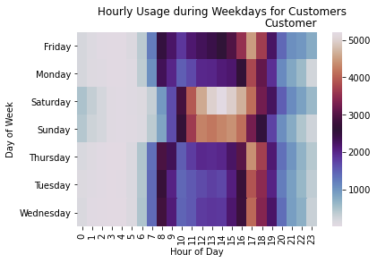

```python
plt.suptitle('Hourly Usage during Weekdays for Customers')
customers = data_df.query('user_type == "Customer"')
ct_counts = customers.groupby(['start_day', 'start_hour']).size()
ct_counts = ct_counts.reset_index(name='count')
ct_counts = ct_counts.pivot(index='start_day', columns='start_hour', values='count')
sb.heatmap(ct_counts, cmap='twilight');
plt.title('Customer', loc='right');
plt.xlabel('Hour of Day');
plt.ylabel('Day of Week');
```

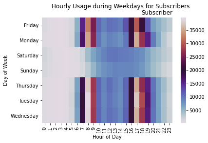

```python
plt.suptitle('Hourly Usage during Weekdays for Subscribers')
subscribers = data_df.query('user_type == "Subscriber"')
st_counts = subscribers.groupby(['start_day', 'start_hour']).size()
st_counts = st_counts.reset_index(name='count')
st_counts = st_counts.pivot(index='start_day', columns='start_hour', values='count')
sb.heatmap(st_counts, cmap='twilight');
plt.title('Subscriber', loc='right');
plt.xlabel('Hour of Day');
plt.ylabel('Day of Week');
```

### Talk about some of the relationships you observed in this part of the investigation. Were there features that strengthened each other in terms of looking at your feature(s) of interest?

We can see what we found on bivariate exploration, we see how Subscribers use the bike to go to the work (most of their trips was on workdays and on work time from 7 to 9 and from 16 to 18. and I think the customer use the bike just for fun because they usually use it on weekend and thier Avg trip duration higher that the subscriber.

### Were there any interesting or surprising interactions between features?

No, we just make sure for what we found on bivariate exploration was true.

> At the end of your report, make sure that you export the notebook as an html file from the `File > Download as... > HTML` menu. Make sure you keep track of where the exported file goes, so you can put it in the same folder as this notebook for project submission. Also, make sure you remove all of the quote-formatted guide notes like this one before you finish your report!